# PredictingStocks_X

Hair Parra

May 10, 2020

# Historical Stocks Data Anlaysis: Forecasting Closing Prices

## Loading packages

```r
library(tidyverse)
library(tidyquant)
library(gridExtra)
library(tibbletime)
library(forecast)
library(itsmr)
library(here)
library(bbmle)
library(tseries)
library(fpp2)
library(ggthemes)
library(readr)
library(xts)
library(reshape)
require(timeDate)
library(png)
knitr::opts_chunk$set(comment=NA,tidy=TRUE)
```

## Loading the data

```r
stocks_3M <- read_csv("../data_raw/stocks_data_3M.csv")
head(stocks_3M, 10)
```

```
# A tibble: 10 x 7
   Date        Open  High   Low Close `Adj Close`   Volume
   <date>     <dbl> <dbl> <dbl> <dbl>       <dbl>    <dbl>
 1 2020-03-04  40.7  41.5  39.8  41.4        41.0 30022100
 2 2020-03-05  40.2  40.5  39.3  39.6        39.2 30255900
 3 2020-03-06  38    40.0  37.8  39.7        39.3 48605600
 4 2020-03-09  36.9  39.6  36.3  38.0        37.6 61535300
 5 2020-03-10  39.2  40.2  37.9  40.1        39.7 50536500
 6 2020-03-11  39.0  39.2  36.4  37.0        36.7 63594300
 7 2020-03-12  34.5  35.8  33    33.2        32.9 51855300
 8 2020-03-13  35.2  37.7  33.3  37.6        37.3 53859600
 9 2020-03-16  33.2  37.0  32.4  33.7        33.4 44211300
10 2020-03-17  34.7  36.2  33.6  35.5        35.2 41572400
```

## Data Preprocessing

Next, extract the columns of interest and convert into time series objects

```r
stocks_3M_data <- select(stocks_3M, Date, Close) # extract cols
dates <- as.POSIXct.Date(stocks_3M_data$Date) # extract dates in POSIXct format
stocks_3M_data.ts <- xts(stocks_3M_data$Close,
                        order.by = dates) # 7600
str(stocks_3M_data.ts) # inspect the data
```

```
An 'xts' object on 2020-03-03 19:00:00/2020-04-30 20:00:00 containing:
  Data: num [1:42, 1] 41.4 39.6 39.7 38 40.1 ...
  Indexed by objects of class: [POSIXct,POSIXt] TZ:
  xts Attributes:
 NULL
```

## Autoplot, ACF and PACF

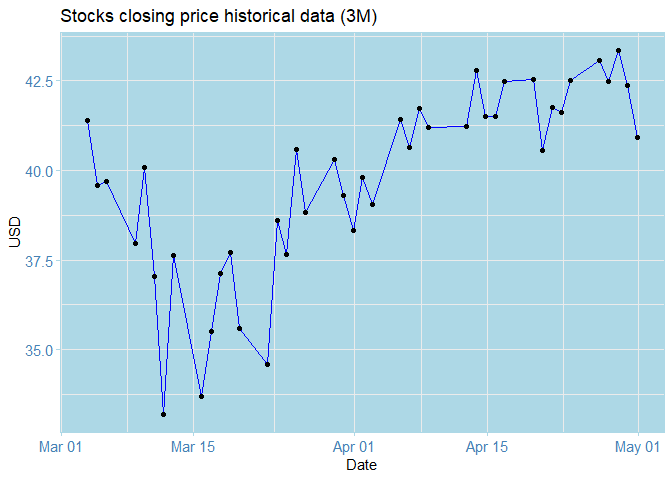

```r
# Plot the same white noice this time as lines
autoplot(stocks_3M_data.ts) +
  geom_line(colour="blue")  +
  ggtitle("Stocks closing price historical data (3M)") +
  theme_stonks() + xlab("Date") + ylab("USD") + geom_point(color="black")
```

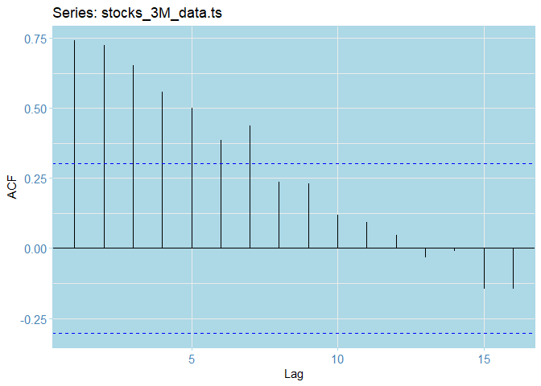

```r
# ACF
ggAcf(stocks_3M_data.ts) + theme_stonks()
```

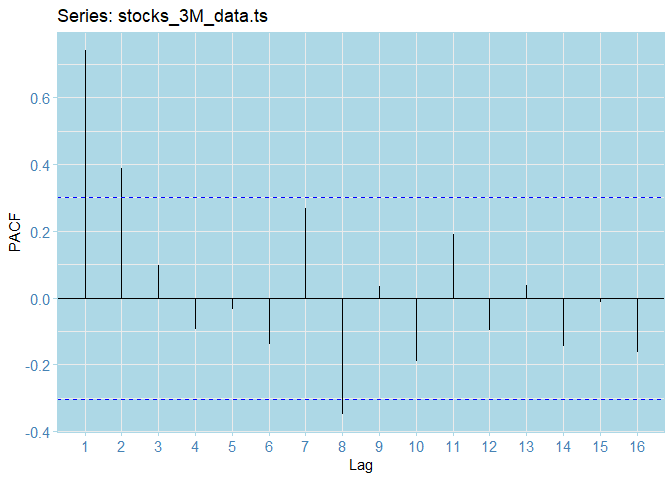

```r
# PACF
ggPacf(stocks_3M_data.ts) + theme_stonks()
```

## Estimating the trend

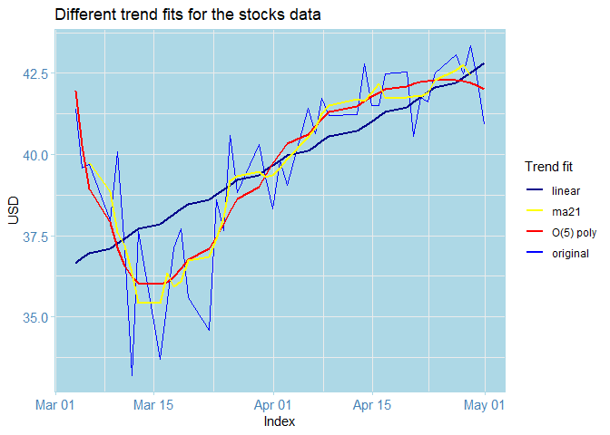

```r
# Estimate various trends
stocks_3M_linear <- tslm(ts(stocks_3M_data.ts)~trend)
stocks_3M_p5 <- tslm(ts(stocks_3M_data.ts)~trend + I(trend^2) + I(trend^3) + I(trend^4) + I(trend^5) ) # polynomial
stocks_3M_ma5 <- ma(ts(stocks_3M_data.ts), order=5) # moving average
stocks_3M_trends <- data.frame(cbind(Data=stocks_3M_data.ts,  # stack in a dataframe
                        Linear_trend=fitted(stocks_3M_linear),
                        Poly_trend=fitted(stocks_3M_p5),
                        Moving_avg5 = stocks_3M_ma5
                        ))

# transform to xts objects
stocks_3M_linear <- xts(fitted(stocks_3M_linear), order.by = dates)
stocks_3M_p5 <- xts(fitted(stocks_3M_p5), order.by = dates)

# Plot all the trends together
autoplot(stocks_3M_data.ts, colour="original") + theme_stonks() +
  geom_line(aes(y=stocks_3M_linear, color="linear"),size=1) +
  geom_line(aes(y=stocks_3M_p5, color = "O(5) poly"), size=1) +
  geom_line(aes(y=stocks_3M_ma5, color ="ma21"), size=1)  +
  scale_color_manual(values = c('original'= 'blue',
                                'linear' = 'darkblue',
                                'O(5) poly' = 'red',
                                'ma21'= 'yellow')) +
  labs(color = 'Trend fit') +  ylab("USD") +
  ggtitle("Different trend fits for the stocks data")
```

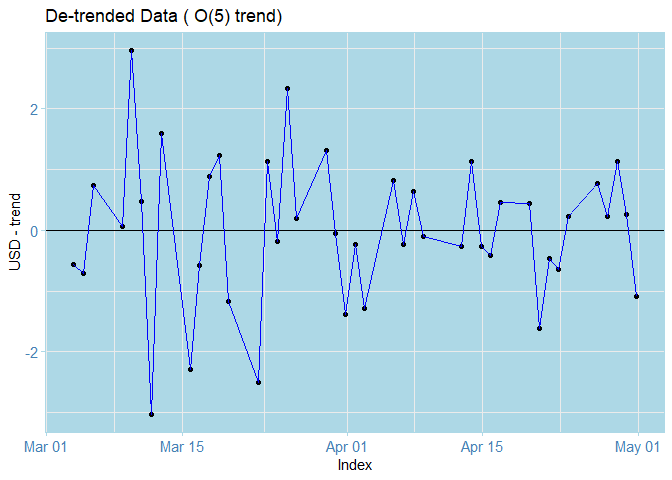

```r
# Detrend and show the de-trended series
stocks_3M_ma21 <- xts(stocks_3M_p5,order.by = dates) # cast to xts
detrend_stocks_3M <- stocks_3M_data.ts - stocks_3M_p5 # substract from original

# Plot the residuals
autoplot(detrend_stocks_3M) + theme_stonks() +
  ggtitle("De-trended Data ( O(5) trend)") +
  geom_hline(yintercept = 0, colour="black") +
  geom_point() + ylab("USD - trend")  + geom_line(color="blue")
```

The residuals look zero-trended.

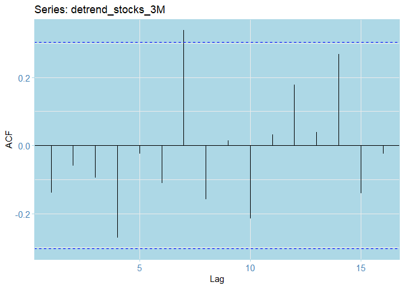

```r
# ACF
ggAcf(detrend_stocks_3M) + theme_stonks()
```

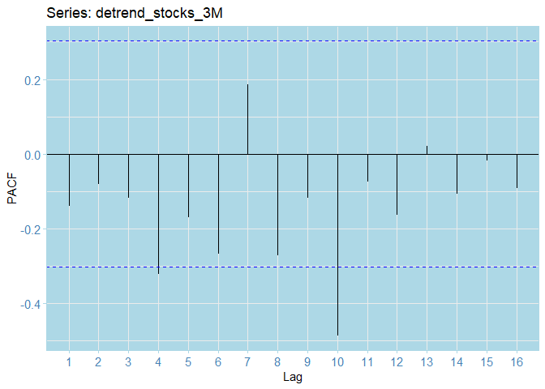

```r
# PACF
ggPacf(detrend_stocks_3M) + theme_stonks()
```

The PACF residuals mostly fall within the confidence bounds; whoever there seems to be some negative autocorrelation present across lags. However, from all the previous, there doesn’t seem to be a strong seasonal component present.

## Train-test split & ARIMA fitting

We will now split the data into 32 training data points and 10 test data points. We will produce predictions and compare them to assess fit.

```r
## train_test_split
detrend_stocks_3M_train <- stocks_3M_data.ts[1:(round(length(detrend_stocks_3M))-10)] # 32
detrend_stocks_3M_test <- stocks_3M_data.ts[(round(length(detrend_stocks_3M))-9):length(detrend_stocks_3M)] # 10
str(detrend_stocks_3M_train)
```

```
An 'xts' object on 2020-03-03 19:00:00/2020-04-16 20:00:00 containing:
  Data: num [1:32, 1] 41.4 39.6 39.7 38 40.1 ...
  Indexed by objects of class: [POSIXct,POSIXt] TZ:
  xts Attributes:
 NULL
```

```r
str(detrend_stocks_3M_test)
```

```
An 'xts' object on 2020-04-19 20:00:00/2020-04-30 20:00:00 containing:
  Data: num [1:10, 1] 42.5 40.5 41.8 41.6 42.5 ...
  Indexed by objects of class: [POSIXct,POSIXt] TZ:
  xts Attributes:
 NULL
```

```r
length(detrend_stocks_3M_train)
```

```
[1] 32
```

```r
length(detrend_stocks_3M_test)
```

```
[1] 10
```

```r
# Fit the ARIMA model on trian data
detrend_stocks_3M_arima_110 = auto.arima(detrend_stocks_3M_train,
                       seasonal=TRUE,
                       stepwise=FALSE,
                       max.d = 2,
                       ic = c("aicc", "aic", "bic") ,
                       approximation=FALSE,
                       trace=TRUE)
```

```
 ARIMA(0,1,0)                    : 134.4715
 ARIMA(0,1,0) with drift         : 136.753
 ARIMA(0,1,1)                    : 128.4086
 ARIMA(0,1,1) with drift         : 130.7508
 ARIMA(0,1,2)                    : 129.5682
 ARIMA(0,1,2) with drift         : 132.1684
 ARIMA(0,1,3)                    : 132.2178
 ARIMA(0,1,3) with drift         : 135.0296
 ARIMA(0,1,4)                    : 134.9037
 ARIMA(0,1,4) with drift         : 137.877
 ARIMA(0,1,5)                    : Inf
 ARIMA(0,1,5) with drift         : Inf
 ARIMA(1,1,0)                    : 128.0794
 ARIMA(1,1,0) with drift         : 130.4957
 ARIMA(1,1,1)                    : 129.8294
 ARIMA(1,1,1) with drift         : 132.4015
 ARIMA(1,1,2)                    : 132.2178
 ARIMA(1,1,2) with drift         : 135.0353
 ARIMA(1,1,3)                    : 134.9886
 ARIMA(1,1,3) with drift         : 138.0829
 ARIMA(1,1,4)                    : Inf
 ARIMA(1,1,4) with drift         : Inf
 ARIMA(2,1,0)                    : 129.5882
 ARIMA(2,1,0) with drift         : 132.1668
 ARIMA(2,1,1)                    : Inf
 ARIMA(2,1,1) with drift         : Inf
 ARIMA(2,1,2)                    : 134.9701
 ARIMA(2,1,2) with drift         : 138.0537
 ARIMA(2,1,3)                    : Inf
 ARIMA(2,1,3) with drift         : Inf
 ARIMA(3,1,0)                    : 132.1147
 ARIMA(3,1,0) with drift         : 134.9255
 ARIMA(3,1,1)                    : 134.9128
 ARIMA(3,1,1) with drift         : 137.9894
 ARIMA(3,1,2)                    : Inf
 ARIMA(3,1,2) with drift         : Inf
 ARIMA(4,1,0)                    : 134.9736
 ARIMA(4,1,0) with drift         : 138.0206
 ARIMA(4,1,1)                    : Inf
 ARIMA(4,1,1) with drift         : 141.3562
 ARIMA(5,1,0)                    : 137.4053
 ARIMA(5,1,0) with drift         : 140.7549



 Best model: ARIMA(1,1,0)
```

```r
detrend_stocks_3M_arima_110
```

```
Series: detrend_stocks_3M_train
ARIMA(1,1,0)

Coefficients:
          ar1
      -0.4935
s.e.   0.1541

sigma^2 estimated as 3.237:  log likelihood=-61.83
AIC=127.65   AICc=128.08   BIC=130.52
```

## Inspecting the residuals

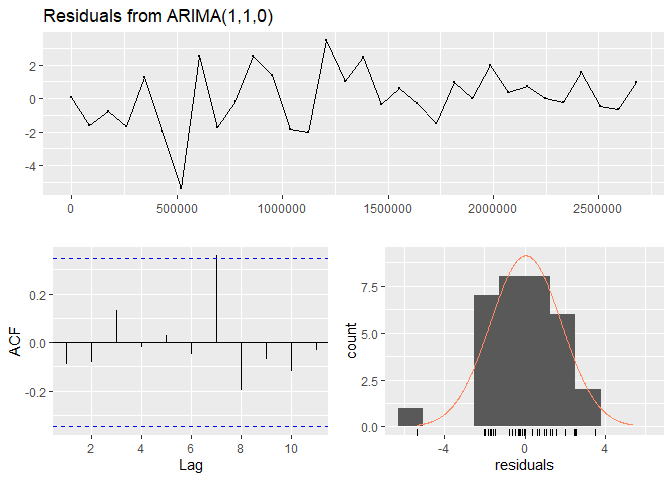

```
    Ljung-Box test

data:  Residuals from ARIMA(1,1,0)
Q* = 1.3259, df = 5, p-value = 0.9322

Model df: 1.   Total lags used: 6
```

```r
checkresiduals(detrend_stocks_3M_arima_110)
```

```r
# check the residuals
train_dates <- as.POSIXct.Date(stocks_3M_data$Date[1: (length(stocks_3M_data$Date) - 10 )])
arima_res <- xts(residuals(detrend_stocks_3M_arima_110),
                 order.by = train_dates)
```

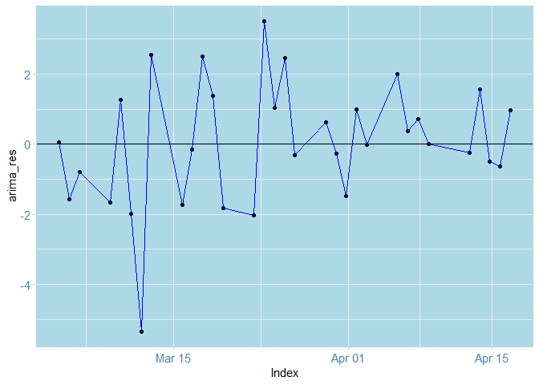

```r
# Plot the residuals
autoplot(arima_res) + theme_stonks() +
  geom_point() + geom_line(color="blue") +
  geom_hline(yintercept = 0, colour="black")
```

We see that perhaps around Mars 13, there could have been a possible outlier.

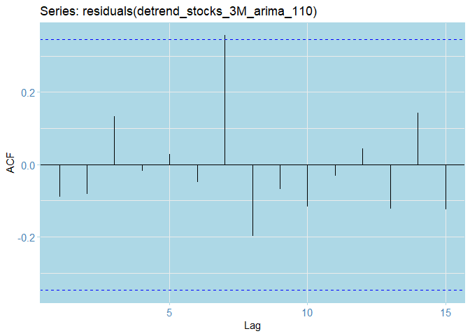

```r
# ACF
ggAcf(residuals(detrend_stocks_3M_arima_110)) + theme_stonks()
```

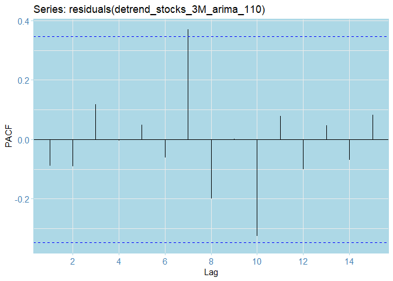

```r
# PACF
ggPacf(residuals(detrend_stocks_3M_arima_110)) + theme_stonks()
```

In both cases, the ACF and PACF points find whithin confidence bounds, with the exception of one. This one might be due to the possible utlier we had before.

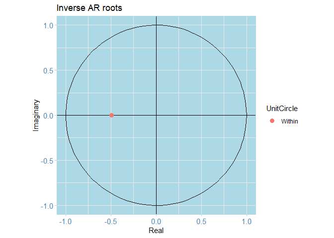

```r
# Inspect roots
autoplot(detrend_stocks_3M_arima_110) + theme_stonks()
```

The roots of the AR(1) polynomial guarantee the process is stationary and causal, and of course, it is also invertible. We can also verify this by performing the ADF and KPSS tests for stationarity:

```r
# Test with a bunch of different k's ? (bigger augmented versions)
detrend_stocks_3M_arima_110_diff <- diff(residuals(detrend_stocks_3M_arima_110), lag=1) # difference order 1
adf.test(detrend_stocks_3M_arima_110_diff,k=1) # ADF
```

```
    Augmented Dickey-Fuller Test

data:  detrend_stocks_3M_arima_110_diff
Dickey-Fuller = -7.2389, Lag order = 1, p-value = 0.01
alternative hypothesis: stationary
```

```r
kpss.test(detrend_stocks_3M_arima_110_diff) # KPSS
```

```
    KPSS Test for Level Stationarity

data:  detrend_stocks_3M_arima_110_diff
KPSS Level = 0.055657, Truncation lag parameter = 2, p-value = 0.1
```

Reject -> stationary for the ADF, fail to reject -> stationary for the KPSS. Now we can proceed with the forecasting.

## Forecasting

### Obtaining model and trend forecasts

We will now forecast 10 observations from both the main model and the trend

```r
detrend_stocks_3M_arima_110_forecasts <- forecast::forecast(detrend_stocks_3M_arima_110,h=10) # ARIMA(1,1,0) forecasts
forecasted_trend <- forecast::forecast( stocks_3M_p5, h=10)  # forecast 10 trend observations
```

### Model forecasts

Let’s produce a table with the point forecast values along with the errors and confidence intervals for predictions

[output not shown]

```r
# Show the table with errors
forecast_table = as.data.frame(forecast_table)
colnames(forecast_table) <- c("Point_Forecast","Lo80","Hi80","Lo95","Hi95","observed","errors")
forecast_table
```

```
   Point_Forecast     Lo80     Hi80     Lo95     Hi95 observed     errors
1        41.99639 39.69064 44.30213 38.47005 45.52272    42.54 -0.5436159
2        42.23504 39.65039 44.81969 38.28216 46.18793    40.55  1.6850426
3        42.11727 39.00740 45.22714 37.36114 46.87340    41.76  0.3572703
4        42.17539 38.74312 45.60766 36.92618 47.42459    41.62  0.5553886
5        42.14671 38.36444 45.92898 36.36223 47.93119    42.52 -0.3732934
6        42.16086 38.08401 46.23771 35.92585 48.39587    43.06 -0.8991408
7        42.15388 37.79058 46.51717 35.48079 48.82696    42.49 -0.3361264
8        42.15732 37.53075 46.78389 35.08159 49.23305    43.34 -1.1826776
9        42.15562 37.27741 47.03383 34.69504 49.61620    42.38 -0.2243795
10       42.15646 37.04017 47.27275 34.33177 49.98115    40.92  1.2364629
```

Extract the values as plain vectors for plotting: we paste this to a bunch of `NA` values to be able to plot all together.

```r
predicts <- c(rep(NA,32),forecast_table$Point_Forecast)
predicts_Lo80 <-  c(rep(NA,32),forecast_table$Lo80)
predicts_Hi80 <-  c(rep(NA,32),forecast_table$Hi80)
predicts_Lo95 <-  c(rep(NA,32),forecast_table$Lo95)
predicts_Hi95 <-  c(rep(NA,32),forecast_table$Hi95)
```

### Producing the forecasts

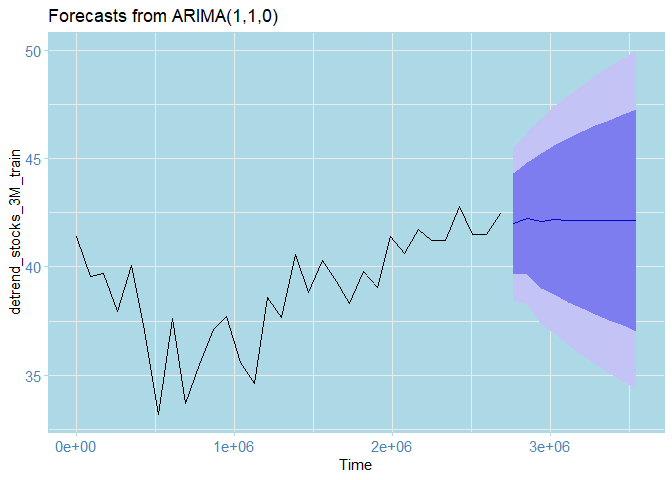

```r
# Plot the predictions + xlim(1.05e+08,1.09e+08) + ylim(32,45)
autoplot(detrend_stocks_3M_arima_110_forecasts)  + theme_stonks()
```

Although this plot looks pretty, notice the scale is somehow very off! We will construct a better plot manually, by using the values we obtained before, so that we can see both the original data and the repdictions along with the confidence intervals like above.

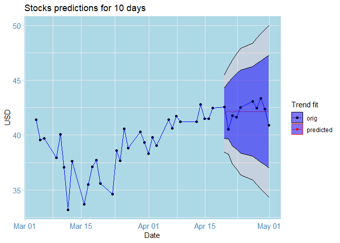

```r
autoplot(stocks_3M_data.ts, colour="orig") + theme_stonks() +
  geom_line(aes(y=predicts,colour = "predicted") ) +
   geom_ribbon(aes(x=as.POSIXct.Date(stocks_3M_data$Date),
                   ymin=predicts_Lo95,ymax=predicts_Hi95),fill="pink", alpha=.3) +
   geom_ribbon(aes(x=as.POSIXct.Date(stocks_3M_data$Date),
                   ymin=predicts_Lo80,ymax=predicts_Hi80),fill="blue", alpha=.5) +
    scale_color_manual(values = c('predicted'= 'red',
                                  'orig'='black')
                       ) +
  ylab("USD") + xlab("Date") + geom_point() + geom_line(color="blue") +
  labs(color = 'Trend fit') + ggtitle("Stocks predictions for 10 days")
```